# Analysis of the Effect of Banning Single-Family Zoning Laws on Housing Prices in Minneapolis

### References

#### W Lazarus, S.T., 2022. Minnesota Department of Revenue real estate transaction data. [Online] Available at: https://doi.org/10.7910/DVN/IO28LF

```r
setwd('/Users/andrewscpu/Documents/GitHub/Minneapolis')
#install packages
#install.packages("dplyr")
#install.packages("readr")
#install.packages("tidyverse")
#install.packages("modelsummary")
#install.packages("fixest")
#install.packages("foreign")
#install.packages("lubridate")
#install.packages("AER")
#install.packages("stargazer")
#install.packages("zoo")
#install.packages("ggplot2")
#install.packages("readr")
#install.packages("data.table")
#install.packages("skimr")
#install.packages("scales")
#install.packages("Ecdat")
#install.packages("here")
#library(Ecdat)
#install.packages('flextable')
# Load libraries
library(flextable)
library(tidyverse)
library(modelsummary)
library(AER)
library(fixest)
library(lubridate)
library(scales)
library(skimr)
library(here)
library(skimr)
library(scales)
library(ggplot2)
library(modelsummary)
library(AER)
library(stargazer)
library(fixest)
library(dplyr)
library(readr)
library(tidyverse)
library(foreign)
library(lubridate)
library(zoo)
library(readr)
library(data.table)
```

###### Filter & Name Cities

```r
# Load data
minneapolis_saint_paul <- fread("/Users/andrewscpu/Documents/GitHub/Minneapolis/Minneapolis_Saint_Paul.csv")
# Filter & rename cities
saint_paul <- minneapolis_saint_paul %>%
  filter(cty_twnshp_nme == "St. Paul") %>%
  rename(purchase_price = tot_purch_amt)

minneapolis <- minneapolis_saint_paul %>%
  filter(cty_twnshp_nme == "Minneapolis") %>%
  rename(purchase_price = tot_purch_amt)

# Convert dates to year-quarter format
saint_paul <- saint_paul %>%
  mutate(date = as.yearqtr(dates, format = "%Y-Q%"))

minneapolis <- minneapolis %>%
  mutate(date = as.yearqtr(dates, format = "%Y-Q%"))
```

# Preprocessing

```r
# Cap sales amount at two standard deviations away from the mean, $1,550,045
saint_paul <- saint_paul %>%
  mutate(purchase_price = pmin(purchase_price, mean(purchase_price) + 2 * sd(purchase_price), 1550045))

minneapolis <- minneapolis %>%
  mutate(purchase_price = pmin(purchase_price, mean(purchase_price) + 2 * sd(purchase_price), 1550045))

# Calculate quarterly aggregate means
saint_paul_agg <- saint_paul %>%
  group_by(date) %>%
  summarize(mean_purchase_price = mean(purchase_price))

minneapolis_agg <- minneapolis %>%
  group_by(date) %>%
  summarize(mean_purchase_price = mean(purchase_price))
```

###### Create quarterly aggregate means

```r
# Create quarterly aggregate means
#aggregated_data_M <- aggregate(tot_purch_amt ~ dates, data = Minneapolis, FUN = mean)
##aggregated_data_SPM <- aggregate(tot_purch_amt ~ dates, data = Minneapolis_Saint_Paul, FUN = mean)
```

## Graph of Minneapolis

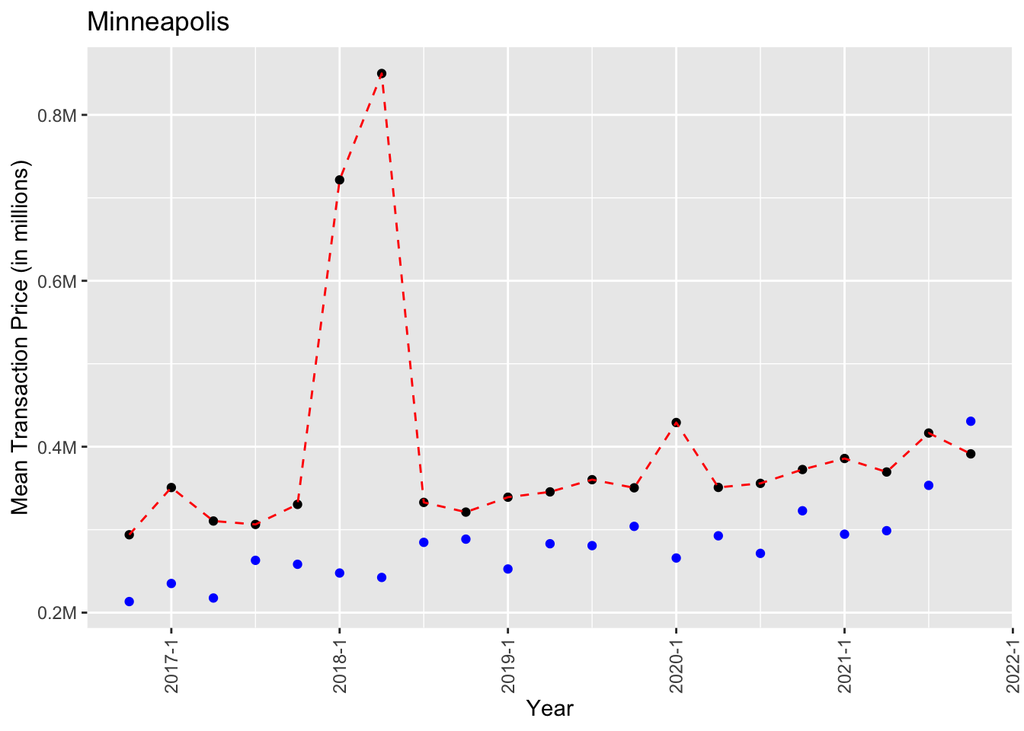

```r
# Rename columns
colnames(minneapolis_agg) <- c("dates", "M")
colnames(saint_paul_agg) <- c("dates", "SP")

# Merge data frames
MSP <- merge(minneapolis_agg, saint_paul_agg, by = "dates")

# Create plot
p <- ggplot(minneapolis_agg, aes(x = dates, y = M)) +
  geom_point(color = "black") +
  geom_line(color = "red", linetype = "dashed") +
  labs(title = "Minneapolis", x = "Year", y = "Mean Transaction Price (in millions)") +
  theme(axis.text.x = element_text(angle = 90, vjust = 0.5)) +
  scale_y_continuous(labels = label_number(suffix = "M", scale = 1e-6))

# Add points to plot
p <- p + geom_point(data = MSP, aes(x = dates, y = SP), color = "blue")
plot(p)
```

###### Graph of Saint Paul

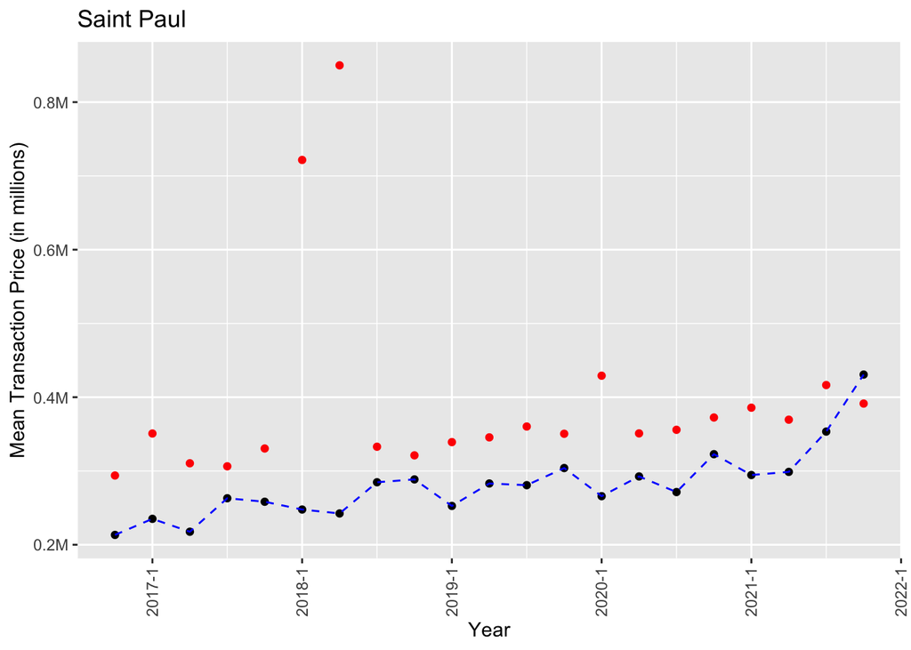

```r
# Create plot
p <- ggplot(saint_paul_agg, aes(x = dates, y = SP)) +
  geom_point(color = "black") +
  geom_line(color = "blue", linetype = "dashed") +
  labs(title = "Saint Paul", x = "Year", y = "Mean Transaction Price (in millions)") +
  theme(axis.text.x = element_text(angle = 90, vjust = 0.5)) +
  scale_y_continuous(labels = label_number(suffix = "M", scale = 1e-6))

# Add points to plot
p <- p + geom_point(data = MSP, aes(x = dates, y = M), color = "red")
plot(p)
```